# ForestGEO Panama — Tree Height Allometry, Small Plots 2011–2020

plant_scaling_data project

2026-05-01

# 1 Overview

**ForestGEO Panama small-plots allometry** is a dataset of individual tree height and diameter measurements collected across 24 small (mostly 1-ha) forest plots in central Panama between 2011 and 2020. It was compiled as part of the Smithsonian ForestGEO network to support allometric model development for tropical forests.

> Ramos P, Villareal P, Muller-Landau HC (2024). *Tree height allometry data for 5,109 trees in twenty-four small ForestGEO plots in Panama, 2011–2020.* Smithsonian Figshare. doi: 10.25573/data.24954204.v1 License: CC BY 4.0

> **⚠ Citation note:** The DOI and author list above are taken directly from the Figshare landing page and should be verified against the source before use in any manuscript.

# 2 Top-level summary

```r
n_spp   <- length(unique(dat$LatinBinomial[!is.na(dat$LatinBinomial)]))
n_plots <- length(unique(dat$Plotname))

kable(data.frame(
  Metric = c(
    "Total individual trees",
    "Unique plots",
    "Unique species (LatinBinomial)",
    "Measurement years",
    "DBH range (display in cm; raw in mm)",
    "Height range (m)",
    "Height-of-measurement (HOM) range (m)",
    "Global lat/lon coverage",
    "AGB estimates in source file",
    "Data license",
    "Source"
  ),
  Value = c(
    format(nrow(dat), big.mark = ","),
    n_plots,
    n_spp,
    paste0(min(dat$YYYY), "\u20132020"),
    paste0(round(min(dat$DBH_cm), 1), "\u2013",
           round(max(dat$DBH_cm), 1), " cm"),
    paste0(round(min(dat$TreeHt_m, na.rm = TRUE), 1), "\u2013",
           round(max(dat$TreeHt_m, na.rm = TRUE), 1), " m"),
    paste0(round(min(dat$HOM_m), 1), "\u2013",
           round(max(dat$HOM_m), 1),
           " m  (non-standard; elevated above buttresses)"),
    paste0("None \u2014 plot-local Cartesian coords only (PX_m, PY_m). ",
           "Plots in central Panama."),
    "None \u2014 raw diameters and heights only; no AGB in source file",
    "CC BY 4.0",
    "Smithsonian Figshare doi:10.25573/data.24954204.v1"
  ),
  stringsAsFactors = FALSE
), caption = "ForestGEO Panama small-plots top-level summary")
```

ForestGEO Panama small-plots top-level summary

| Metric | Value |
| --- | --- |
| Total individual trees | 5,109 |
| Unique plots | 24 |
| Unique species (LatinBinomial) | 353 |
| Measurement years | 2011–2020 |
| DBH range (display in cm; raw in mm) | 1.5–229.7 cm |
| Height range (m) | 0–42.2 m |
| Height-of-measurement (HOM) range (m) | 0.3–4.8 m (non-standard; elevated above buttresses) |
| Global lat/lon coverage | None — plot-local Cartesian coords only (PX_m, PY_m). Plots in central Panama. |
| AGB estimates in source file | None — raw diameters and heights only; no AGB in source file |
| Data license | CC BY 4.0 |
| Source | Smithsonian Figshare doi:10.25573/data.24954204.v1 |

# 3 Data dictionary

```r
kable(dd, caption = "Variable definitions (from source xlsx data dictionary)")
```

Variable definitions (from source xlsx data dictionary)

| Attribute name | Attribute Label | Category | Character type | Units | Definition |
| --- | --- | --- | --- | --- | --- |
| UniqueID | Unique tree ID | Anything | String | NA | Combination of plotname and tag that is unique for each tree (the same tag number may appear in different plots) |
| PX_m | X cartesian coordinates | Numeric | Non-integer | Meters | Location of the tree within the plot along a cartesian X axis (in m) |
| PY_m | Y cartesian coordinates | Numeric | Non-integer | Meters | Location of the tree within the plot along a cartesian Y axis (in m) |
| Plotname | Plot name | Unordered category | String | NA | Code for the plot in which the tree is located |
| Tag | Tree tag | Numeric | Integer | NA | Tag number of the tree |
| Stem | Stem number | Ordered category | Integer | NA | Stem number - blank if there is only one stem ever |
| MultiStem | Multiple-stemmed | Unordered category | Boolean | NA | True/false - Are there multiple stems of this tree in this dataset? |
| sp6 | 6 letter species code | Anything | String | NA | 6-letter code for species ID |
| LatinBinomial | Latin binomial | Anything | String | NA | Tree species latin binomial |
| HOM_m | Height of meassurement | Numeric | Non-integer | Meters | Height of measurement (in m); height along stem at which the diameter was measured (marked with paint) |
| DBH_mm | Diameter at breast height | Numeric | Non-integer | Milimeters | Diameter of the stem (in mm) at the paint-marked point |
| Crown | Crown | Ordered category | Integer | NA | Crown intactness score. values 0 to 4. 4 = 75-100% of the crown is intact (no or few branches lost) 3 = 50-75% of the crown is intact 2 = 25-50% of the crown is intact 1 = 0-25% of the crown is intact… |
| Light | Light | Ordered category | Integer | NA | Crown illumination index. values 1 to 5. 5 = crown completely exposed (to vertical light and to lateral light within the 90 degree inverted cone encompassing the crown) 4 = full overhead light (>=90% … |
| Lianas | Lianas | Ordered category | Integer | NA | Liana cover of the crown. values 0 to 4. where 0 is no lianas. 1 is 1-25% covered with lianas. 2 is 26-50%. 3 is 51-75%. and 4 is 76-100% |
| Q | Quebrado | Unordered category | Boolean | NA | True/false - Stem broken above 1.3 m |
| TreeHt_m | Tree Height | Numeric | Non-integer | Meters | Tree height (m) |
| Observer | Observer | Anything | String | NA | Who made the measurements? |
| DD | Day | Numeric | Integer | NA | Day of the month in which the measurement was taken |
| MM | Month | Numeric | Integer | NA | Month of the year in which the measurement was taken |
| YYYY | Year | Numeric | Integer | NA | Year in which the measurement was taken |
| L | Leaning | Unordered category | Boolean | NA | True/false - Is the tree leaning by more than 45 degrees? |
| PP | Placa Perdida | Unordered category | Boolean | NA | True/false - Was the tree tag missing when on the measurement date? |
| R | Resprout | Unordered category | Boolean | NA | True/false - Is the stem a resprout? (Was it broken below 1.3 m) |
| Notes | Notes | Anything | String | NA | Any additional notes made by the field team (mostly in Spanish) |

> **Note:** Column `B` appears in the data file (25 columns total) but has no entry in the 24-row data dictionary. All 5,109 values are `FALSE`. It may represent a broken-below-breast-height flag analogous to `Q` (broken *above* 1.3 m); the exact definition is undocumented in the deposited files.

# 4 Geographic context

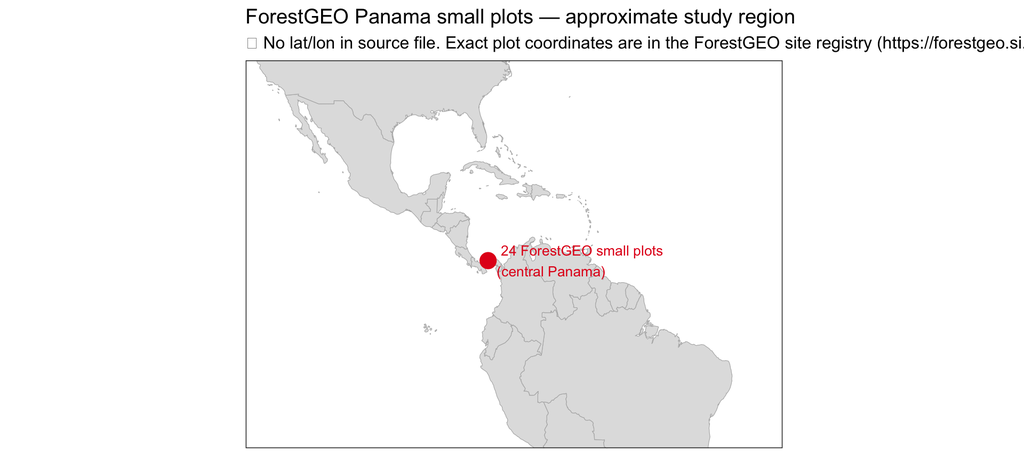

```r
# No global lat/lon in the dataset — plots use local Cartesian coordinates.
# We show the approximate study region in Panama.
world <- map_data("world")

panama_pt <- data.frame(
  label = "24 ForestGEO small plots\n(central Panama)",
  lon   = -79.8,
  lat   =   9.1
)

ggplot() +
  geom_polygon(data = world,
               aes(x = long, y = lat, group = group),
               fill = "grey88", color = "grey70", linewidth = 0.2) +
  geom_point(data = panama_pt,
             aes(x = lon, y = lat),
             color = "#e41a1c", size = 5) +
  geom_text(data = panama_pt,
            aes(x = lon, y = lat, label = label),
            hjust = -0.08, vjust = 0.5, size = 3.5, color = "#e41a1c") +
  coord_fixed(1.3, xlim = c(-120, -30), ylim = c(-15, 35)) +
  labs(
    title    = "ForestGEO Panama small plots \u2014 approximate study region",
    subtitle = paste0("\u26a0 No lat/lon in source file. ",
                      "Exact plot coordinates are in the ForestGEO site registry ",
                      "(https://forestgeo.si.edu/sites)."),
    x = NULL, y = NULL
  ) +
  theme(axis.text = element_blank(), axis.ticks = element_blank(),
        panel.grid = element_blank())
```

# 5 Per-plot tree counts

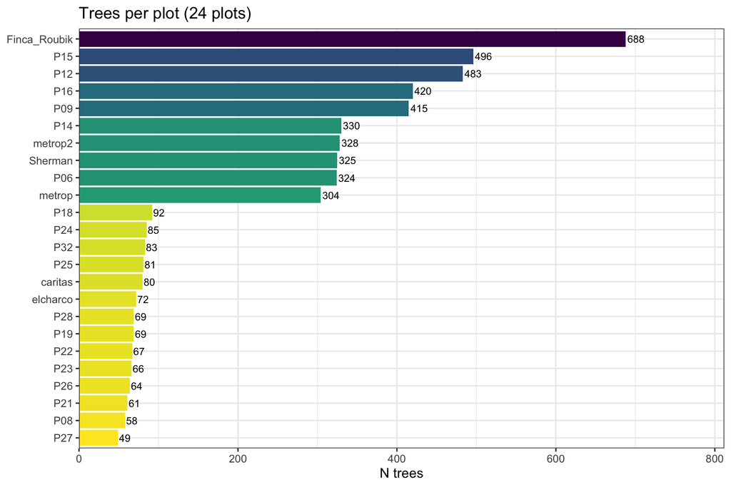

```r
plot_counts <- dat |>
  count(Plotname, name = "n_trees") |>
  arrange(desc(n_trees))

ggplot(plot_counts, aes(x = reorder(Plotname, n_trees), y = n_trees,
                        fill = n_trees)) +
  geom_col(show.legend = FALSE) +
  geom_text(aes(label = n_trees), hjust = -0.1, size = 3.2) +
  coord_flip() +
  scale_fill_viridis_c(option = "D", direction = -1) +
  scale_y_continuous(expand = expansion(mult = c(0, 0.18))) +
  labs(x = NULL, y = "N trees", title = "Trees per plot (24 plots)")
```

```r
kable(plot_counts, caption = "Trees per plot")
```

Trees per plot

| Plotname | n_trees |
| --- | --- |
| Finca_Roubik | 688 |
| P15 | 496 |
| P12 | 483 |
| P16 | 420 |
| P09 | 415 |
| P14 | 330 |
| metrop2 | 328 |
| Sherman | 325 |
| P06 | 324 |
| metrop | 304 |
| P18 | 92 |
| P24 | 85 |
| P32 | 83 |
| P25 | 81 |
| caritas | 80 |
| elcharco | 72 |
| P19 | 69 |
| P28 | 69 |
| P22 | 67 |
| P23 | 66 |
| P26 | 64 |
| P21 | 61 |
| P08 | 58 |
| P27 | 49 |

# 6 Diameter distribution

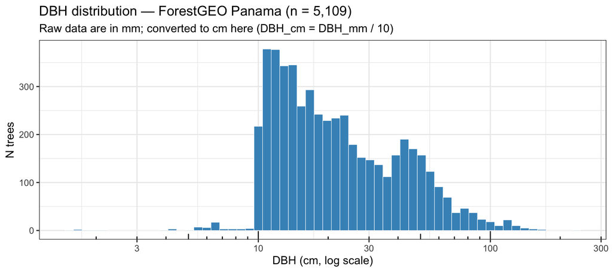

```r
dat |>
  ggplot(aes(x = DBH_cm)) +
  geom_histogram(bins = 60, fill = "#4393c3", color = "white", linewidth = 0.2) +
  scale_x_log10(labels = comma) +
  annotation_logticks(sides = "b") +
  scale_y_continuous(labels = comma) +
  labs(
    x = "DBH (cm, log scale)", y = "N trees",
    title = "DBH distribution \u2014 ForestGEO Panama (n = 5,109)",
    subtitle = "Raw data are in mm; converted to cm here (DBH_cm = DBH_mm / 10)"
  )
```

# 7 Height distribution

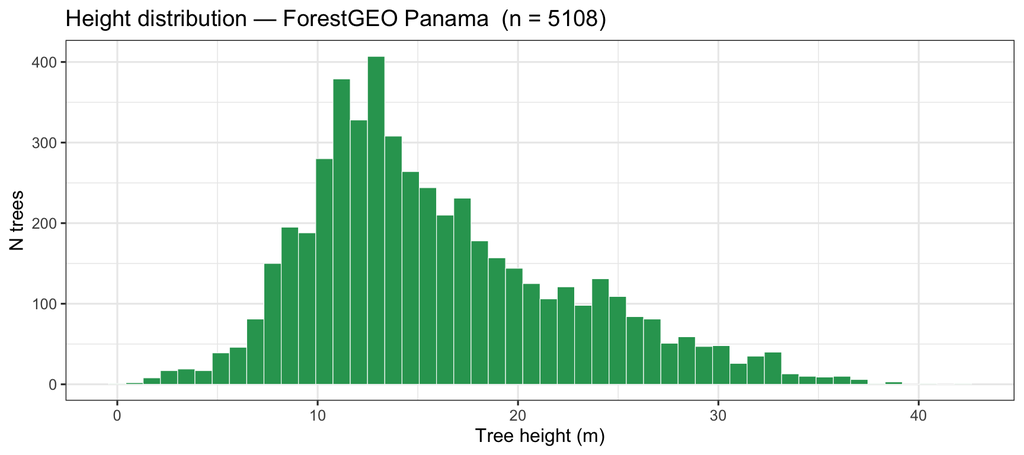

```r
dat |>
  filter(!is.na(TreeHt_m)) |>
  ggplot(aes(x = TreeHt_m)) +
  geom_histogram(bins = 50, fill = "#2ca25f", color = "white", linewidth = 0.2) +
  scale_y_continuous(labels = comma) +
  labs(
    x = "Tree height (m)", y = "N trees",
    title = paste0("Height distribution \u2014 ForestGEO Panama  (n = ",
                   sum(!is.na(dat$TreeHt_m)), ")")
  )
```

# 8 Height ~ DBH scaling

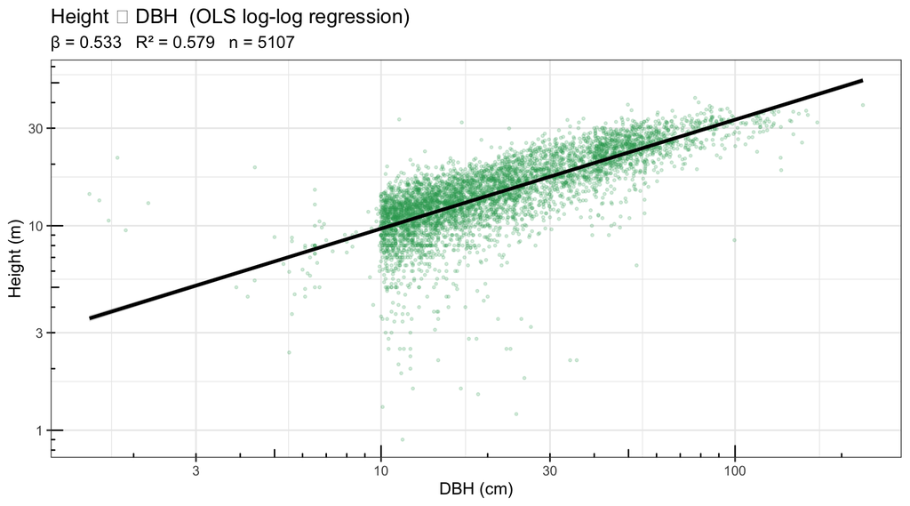

```r
sub <- dat |> filter(!is.na(TreeHt_m), DBH_cm > 0, TreeHt_m > 0)
lm_fit <- lm(log(TreeHt_m) ~ log(DBH_cm), data = sub)
beta <- round(coef(lm_fit)[2], 3)
r2   <- round(summary(lm_fit)$r.squared, 3)

sub |>
  ggplot(aes(x = DBH_cm, y = TreeHt_m)) +
  geom_point(alpha = 0.2, size = 0.7, color = "#2ca25f") +
  geom_smooth(method = "lm", color = "black", linewidth = 1.2, se = TRUE) +
  scale_x_log10(labels = comma) + scale_y_log10(labels = comma) +
  annotation_logticks() +
  labs(
    x = "DBH (cm)", y = "Height (m)",
    title = "Height \u223c DBH  (OLS log-log regression)",
    subtitle = paste0("\u03b2 = ", beta, "   R\u00b2 = ", r2,
                      "   n = ", nrow(sub))
  )
```

> OLS log-log regression on all individuals with valid DBH and height. $\beta \approx 0.6$–$0.7$ is typical for tropical moist forest. ⚠ This regression pools all plots and species and should not be treated as a formal allometric model — use SMA regression and species-level grouping for inference.

# 9 Height of measurement (HOM)

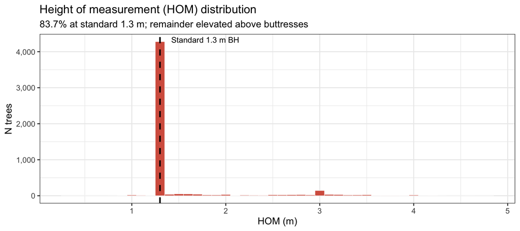

```r
pct_standard <- round(100 * mean(dat$HOM_m == 1.3), 1)

dat |>
  ggplot(aes(x = HOM_m)) +
  geom_histogram(binwidth = 0.1, fill = "#d6604d", color = "white",
                 linewidth = 0.2) +
  geom_vline(xintercept = 1.3, linetype = "dashed", color = "black",
             linewidth = 0.9) +
  annotate("text", x = 1.42, y = Inf, label = "Standard 1.3 m BH",
           hjust = 0, vjust = 1.5, size = 3.5) +
  scale_y_continuous(labels = comma) +
  labs(
    x = "HOM (m)", y = "N trees",
    title = "Height of measurement (HOM) distribution",
    subtitle = paste0(pct_standard, "% at standard 1.3 m; remainder elevated above buttresses")
  )
```

**Key caveat:** Diameter is measured at a paint-marked point (`HOM_m`) ranging from 0.3 to 4.8 m. Trees with `HOM_m > 1.3` are typically buttressed individuals measured above the buttress. This **must be accounted for** in any allometric comparison that assumes DBH at breast height (1.3 m).

# 10 Quality and condition flags

```r
flags <- data.frame(
  Flag = c(
    "Q — stem broken above 1.3 m (Quebrado)",
    "L — leaning > 45\u00b0",
    "PP — tag missing at measurement date (Placa Perdida)",
    "R — resprout (stem broken below 1.3 m)",
    "B — undocumented flag (all FALSE; not in data dictionary)",
    "MultiStem — tree has multiple stems in dataset"
  ),
  N_TRUE = c(
    sum(dat$Q,         na.rm = TRUE),
    sum(dat$L,         na.rm = TRUE),
    sum(dat$PP,        na.rm = TRUE),
    sum(dat$R,         na.rm = TRUE),
    sum(dat$B,         na.rm = TRUE),
    sum(dat$MultiStem, na.rm = TRUE)
  ),
  Pct = paste0(round(100 * c(
    mean(dat$Q,         na.rm = TRUE),
    mean(dat$L,         na.rm = TRUE),
    mean(dat$PP,        na.rm = TRUE),
    mean(dat$R,         na.rm = TRUE),
    mean(dat$B,         na.rm = TRUE),
    mean(dat$MultiStem, na.rm = TRUE)
  ), 1), "%"),
  stringsAsFactors = FALSE
)
kable(flags, caption = "Quality and condition flag counts (n = 5,109 trees)")
```

Quality and condition flag counts (n = 5,109 trees)

| Flag | N_TRUE | Pct |
| --- | --- | --- |
| Q — stem broken above 1.3 m (Quebrado) | 380 | 7.4% |
| L — leaning > 45° | 43 | 0.8% |
| PP — tag missing at measurement date (Placa Perdida) | 13 | 0.3% |
| R — resprout (stem broken below 1.3 m) | 2 | 0% |
| B — undocumented flag (all FALSE; not in data dictionary) | 0 | 0% |
| MultiStem — tree has multiple stems in dataset | 551 | 10.8% |

# 11 Crown intactness

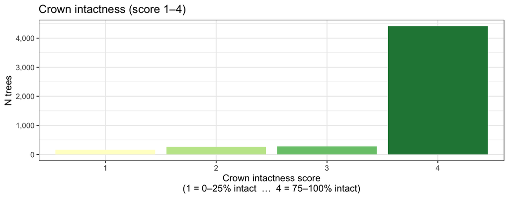

```r
dat |>
  filter(!is.na(Crown)) |>
  count(Crown) |>
  ggplot(aes(x = factor(Crown), y = n, fill = factor(Crown))) +
  geom_col(show.legend = FALSE) +
  scale_fill_brewer(palette = "YlGn") +
  scale_y_continuous(labels = comma) +
  labs(
    x = "Crown intactness score\n(1 = 0\u201325% intact  \u2026  4 = 75\u2013100% intact)",
    y = "N trees",
    title = "Crown intactness (score 1\u20134)"
  )
```

# 12 Crown illumination

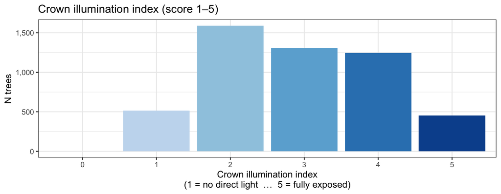

```r
dat |>
  filter(!is.na(Light)) |>
  count(Light) |>
  ggplot(aes(x = factor(Light), y = n, fill = factor(Light))) +
  geom_col(show.legend = FALSE) +
  scale_fill_brewer(palette = "Blues") +
  scale_y_continuous(labels = comma) +
  labs(
    x = paste0("Crown illumination index\n",
               "(1 = no direct light  \u2026  5 = fully exposed)"),
    y = "N trees",
    title = "Crown illumination index (score 1\u20135)"
  )
```

# 13 Liana infestation

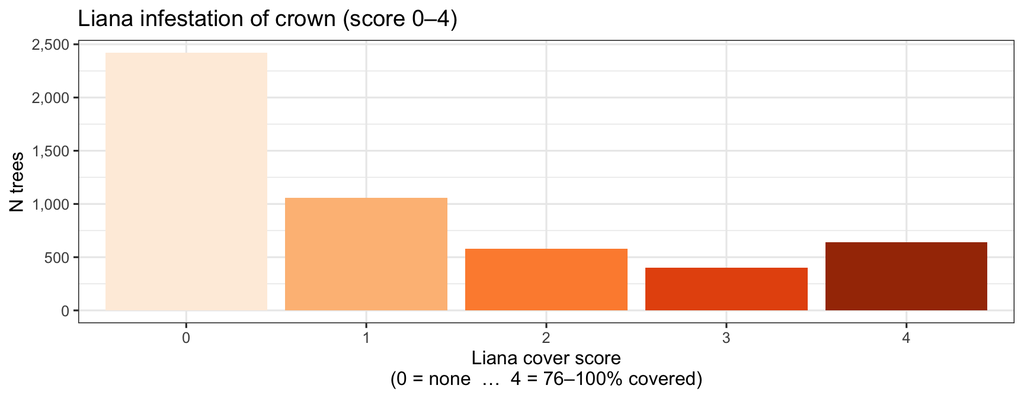

```r
dat |>
  filter(!is.na(Lianas)) |>
  count(Lianas) |>
  ggplot(aes(x = factor(Lianas), y = n, fill = factor(Lianas))) +
  geom_col(show.legend = FALSE) +
  scale_fill_brewer(palette = "Oranges") +
  scale_y_continuous(labels = comma) +
  labs(
    x = "Liana cover score\n(0 = none  \u2026  4 = 76\u2013100% covered)",
    y = "N trees",
    title = "Liana infestation of crown (score 0\u20134)"
  )
```

# 14 Top 20 most abundant species

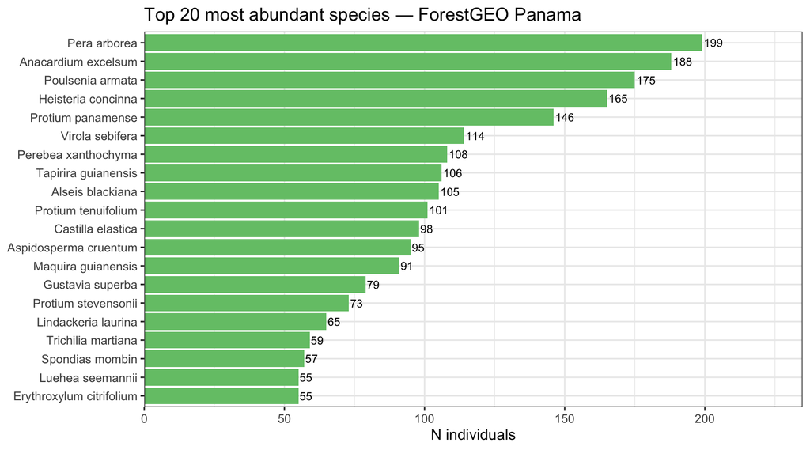

```r
dat |>
  count(LatinBinomial, sort = TRUE) |>
  head(20) |>
  ggplot(aes(x = reorder(LatinBinomial, n), y = n)) +
  geom_col(fill = "#74c476") +
  geom_text(aes(label = n), hjust = -0.1, size = 3.2) +
  coord_flip() +
  scale_y_continuous(expand = expansion(mult = c(0, 0.18))) +
  labs(
    x = NULL, y = "N individuals",
    title = "Top 20 most abundant species \u2014 ForestGEO Panama"
  )
```

# 15 Measurements per year

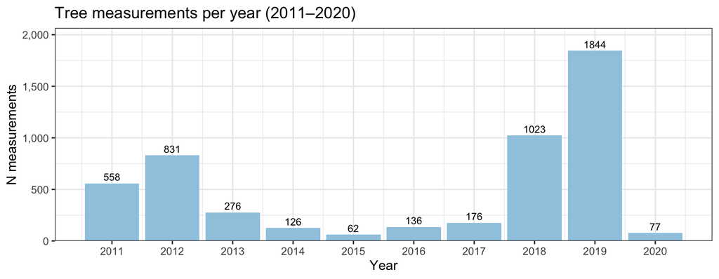

```r
dat |>
  count(YYYY) |>
  ggplot(aes(x = YYYY, y = n)) +
  geom_col(fill = "#9ecae1") +
  geom_text(aes(label = n), vjust = -0.4, size = 3.2) +
  scale_y_continuous(labels = comma, expand = expansion(mult = c(0, 0.12))) +
  scale_x_continuous(breaks = 2011:2020) +
  labs(x = "Year", y = "N measurements",
       title = "Tree measurements per year (2011\u20132020)")
```

# 16 Data completeness

```r
key_cols <- c("DBH_mm", "TreeHt_m", "HOM_m", "LatinBinomial",
              "Plotname", "Crown", "Light", "Lianas", "YYYY", "Observer")

compl_df <- data.frame(
  Column       = key_cols,
  N_nonNA      = sapply(key_cols, function(c) sum(!is.na(dat[[c]]))),
  Pct_complete = paste0(
    sapply(key_cols, function(c) round(100 * mean(!is.na(dat[[c]])), 1)),
    "%"
  ),
  stringsAsFactors = FALSE
)
kable(compl_df, caption = "Completeness of key variables (n = 5,109 trees)")
```

Completeness of key variables (n = 5,109 trees)

|  | Column | N_nonNA | Pct_complete |
| --- | --- | --- | --- |
| DBH_mm | DBH_mm | 5109 | 100% |
| TreeHt_m | TreeHt_m | 5108 | 100% |
| HOM_m | HOM_m | 5109 | 100% |
| LatinBinomial | LatinBinomial | 5109 | 100% |
| Plotname | Plotname | 5109 | 100% |
| Crown | Crown | 5108 | 100% |
| Light | Light | 5107 | 100% |
| Lianas | Lianas | 5098 | 99.8% |
| YYYY | YYYY | 5109 | 100% |
| Observer | Observer | 4691 | 91.8% |

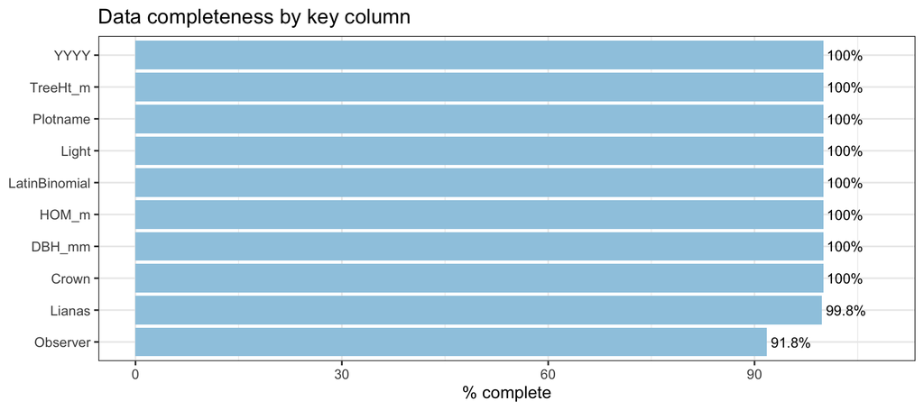

```r
data.frame(
  Column = key_cols,
  pct    = sapply(key_cols, function(c) round(100 * mean(!is.na(dat[[c]])), 1))
) |>
  ggplot(aes(x = reorder(Column, pct), y = pct)) +
  geom_col(fill = "#9ecae1") +
  geom_text(aes(label = paste0(pct, "%")), hjust = -0.1, size = 3.5) +
  coord_flip() +
  scale_y_continuous(limits = c(0, 108)) +
  labs(x = NULL, y = "% complete",
       title = "Data completeness by key column")
```

# 17 Notes for allometric merging

1. **DBH units:** Raw data are in **mm** — convert to cm (`DBH_cm = DBH_mm / 10`) before merging with BAAD, Tallo, Niklas-Enquist, or NEON (all use cm or the equivalent SI unit).
2. **Non-standard HOM:** Diameter is measured at a paint-marked point varying from 0.3 to 4.8 m. Trees with `HOM_m > 1.3 m` are buttressed individuals. Allometries that assume DBH at 1.3 m BH should flag these or apply a buttress correction (e.g., Cushman et al. 2014, *For. Ecol. Manage.*).
3. **No global lat/lon:** The dataset uses plot-local Cartesian coordinates (`PX_m`, `PY_m`). Global coordinates must be retrieved from the ForestGEO site registry (https://forestgeo.si.edu/sites) before any spatial analysis or merging with georeferenced datasets.
4. **No AGB in source:** Only diameters and heights are provided. AGB must be estimated by applying an allometric equation (e.g., Chave et al. 2014 pantropical equation), which requires a wood density lookup (Zanne et al. 2009 backbone via BIOMASS R package).
5. **Taxonomy:** Species are identified to `LatinBinomial` with no authority or taxonomic backbone. TNRS or GBIF name matching is recommended before any cross-source taxonomic merge.
6. **Undocumented `B` column:** All 5,109 values are `FALSE`. No definition appears in the deposited data dictionary; confirm with data depositors if this flag is relevant before excluding or retaining records.